# Stat 585 - Working in teams: Sample solution for the test case

Heike Hofmann

# Solution to the test case

The dataset `brfss_iowa.csv` (linked from website) contains 6227 records from the Behavioral Risk Factor Surveillance System (BRFSS) for Iowans.

> The Behavioral Risk Factor Surveillance System (BRFSS) is the nation’s premier system of health-related telephone surveys that collect state data about U.S. residents regarding their health-related risk behaviors.

It is conducted annually by the Center for Disease Control and Prevention (CDC).

Codebook with detailed explanations of variables is [available here](https://www.cdc.gov/brfss/annual_data/2015/pdf/codebook15_llcp.pdf).

## The Problem

0. Complete the following tasks and **write instructions / documentation** for a collaborator to be able to reproduce your findings.
1. Verify that there are 6227 cases (= number of interviews) in the data.
2. Verify that there are variables `WEIGHT2` and `HEIGHT3` in the data and read the description of the variables in the codebook.
3. How are height and weight related? Find correlations of weight and height by gender (`SEX`). How many values are the correlations based on for each gender?
4. Write a short report of your findings. Address potential problems in the data.

### Read the data and check dimensions

```r
library(tidyverse)
iowa <- readr::read_csv("https://github.com/Stat585-at-ISU/materials/raw/master/01_collaborative-environment/data/brfss_iowa.csv")
# the read_csv function from the readr package is faster than the standard read.csv
# but the output is a tibble (we'll come back to that)

dim(iowa)
```

```
## [1] 6227  330
```

```r
# Yes, there are 6227 observations (rows) in the data set and a lot of columns/variables
head(iowa)
```

```
## # A tibble: 6 x 330
##   X_STATE FMONTH IDATE IMONTH IDAY  IYEAR DISPCODE  SEQNO  X_PSU CTELENUM
##     <int>  <int> <chr> <chr>  <chr> <int>    <int>  <int>  <int>    <int>
## 1      19      7 0708… 07     08     2015     1200 2.02e9 2.02e9       NA
## 2      19      3 0321… 03     21     2015     1200 2.02e9 2.02e9       NA
## 3      19     10 0110… 01     10     2016     1200 2.02e9 2.02e9       NA
## 4      19      4 0509… 05     09     2015     1200 2.02e9 2.02e9       NA
## 5      19      5 0624… 06     24     2015     1200 2.02e9 2.02e9       NA
## 6      19      7 0803… 08     03     2015     1200 2.02e9 2.02e9       NA
## # ... with 320 more variables: PVTRESD1 <int>, COLGHOUS <int>,
## #   STATERES <int>, CELLFON3 <int>, LADULT <int>, NUMADULT <int>,
## #   NUMMEN <int>, NUMWOMEN <int>, CTELNUM1 <int>, CELLFON2 <int>,
## #   CADULT <int>, PVTRESD2 <int>, CCLGHOUS <chr>, CSTATE <int>,
## #   LANDLINE <int>, HHADULT <int>, GENHLTH <int>, PHYSHLTH <int>,
## #   MENTHLTH <int>, POORHLTH <int>, HLTHPLN1 <int>, PERSDOC2 <int>,
## #   MEDCOST <int>, CHECKUP1 <int>, BPHIGH4 <int>, BPMEDS <int>,
## #   BLOODCHO <int>, CHOLCHK <int>, TOLDHI2 <int>, CVDINFR4 <int>,
## #   CVDCRHD4 <int>, CVDSTRK3 <int>, ASTHMA3 <int>, ASTHNOW <int>,
## #   CHCSCNCR <int>, CHCOCNCR <int>, CHCCOPD1 <int>, HAVARTH3 <int>,
## #   ADDEPEV2 <int>, CHCKIDNY <int>, DIABETE3 <int>, DIABAGE2 <int>,
## #   SEX <int>, MARITAL <int>, EDUCA <int>, RENTHOM1 <int>, NUMHHOL2 <int>,
## #   NUMPHON2 <int>, CPDEMO1 <int>, VETERAN3 <int>, EMPLOY1 <int>,
## #   CHILDREN <int>, INCOME2 <int>, INTERNET <int>, WEIGHT2 <int>,
## #   HEIGHT3 <int>, PREGNANT <int>, QLACTLM2 <int>, USEEQUIP <int>,
## #   BLIND <int>, DECIDE <int>, DIFFWALK <int>, DIFFDRES <int>,
## #   DIFFALON <int>, SMOKE100 <int>, SMOKDAY2 <int>, STOPSMK2 <int>,
## #   LASTSMK2 <int>, USENOW3 <int>, ALCDAY5 <int>, AVEDRNK2 <int>,
## #   DRNK3GE5 <int>, MAXDRNKS <int>, FRUITJU1 <int>, FRUIT1 <int>,
## #   FVBEANS <int>, FVGREEN <int>, FVORANG <int>, VEGETAB1 <int>,
## #   EXERANY2 <int>, EXRACT11 <int>, EXEROFT1 <int>, EXERHMM1 <int>,
## #   EXRACT21 <int>, EXEROFT2 <int>, EXERHMM2 <int>, STRENGTH <int>,
## #   LMTJOIN3 <int>, ARTHDIS2 <int>, ARTHSOCL <int>, JOINPAIN <int>,
## #   SEATBELT <int>, FLUSHOT6 <int>, FLSHTMY2 <int>, IMFVPLAC <int>,
## #   PNEUVAC3 <int>, HIVTST6 <int>, HIVTSTD3 <int>, WHRTST10 <int>,
## #   PDIABTST <chr>, …
```

### Variables `HEIGHT3` and `WEIGHT2`

```r
library(tidyverse)
iowa %>% select(HEIGHT3, WEIGHT2) %>% head()
```

```
## # A tibble: 6 x 2
##   HEIGHT3 WEIGHT2
##     <int>   <int>
## 1     511     191
## 2    7777     140
## 3     503     135
## 4     504     115
## 5      NA      NA
## 6     510     210
```

Variables are there … but … some data values look odd.

Let’s follow up by having a look at the Codebook.

From the [codebook](https://www.cdc.gov/brfss/annual_data/2015/pdf/codebook15_llcp.pdf): HEIGHT3 and WEIGHT2 are the originally recorded variables.

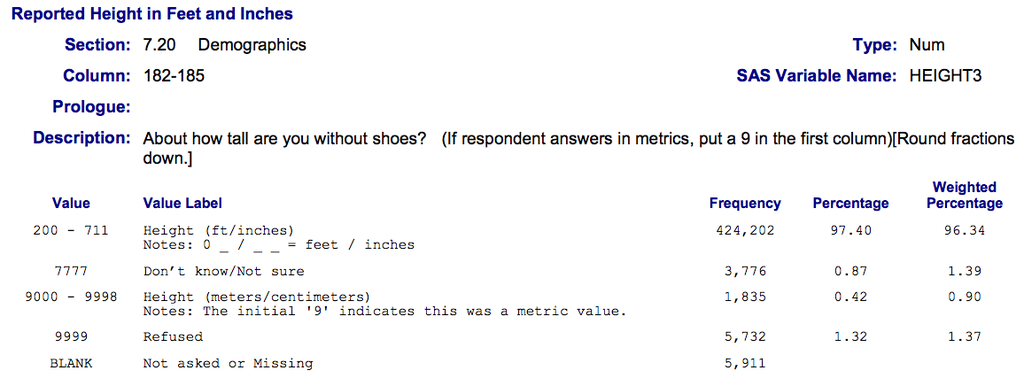

Let’s plot that …

Load the `ggplot2` package to plot weight versus height:

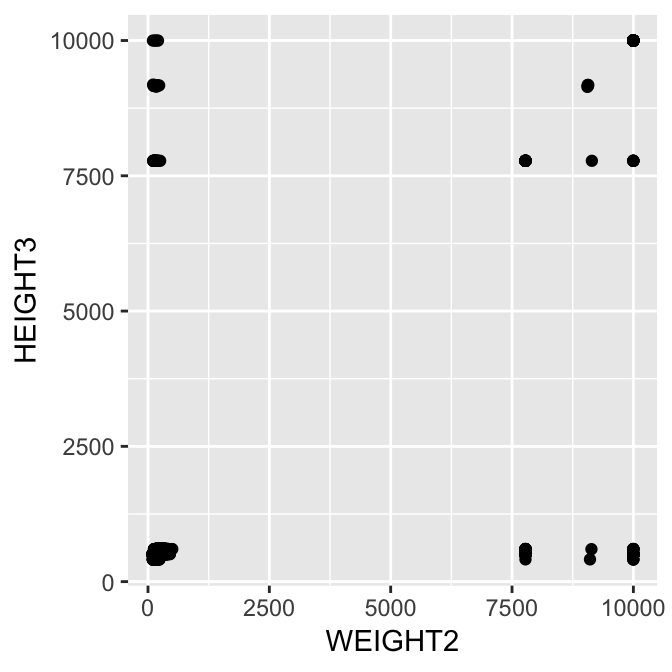

```r
library(ggplot2)
library(tidyverse)
iowa %>%
  ggplot(aes(x = WEIGHT2, y = HEIGHT3)) + geom_point()
```

Height and weight should show a somewhat positive correlation. These clusters are an indication of the data coding.

### Next steps

Obviously, we need to spend some time cleaning these variables before we can make use of them.

We have a couple of choices:

1. We can buckle down and do that clean-up and then move on to the calculation.
2. We can take another look at the variables and investigate what `HTIN4`, `HTM4`, and `WTKG3` are …

## Route 2

Let’s take the second route first and draw a picture of height and weight in metric units:

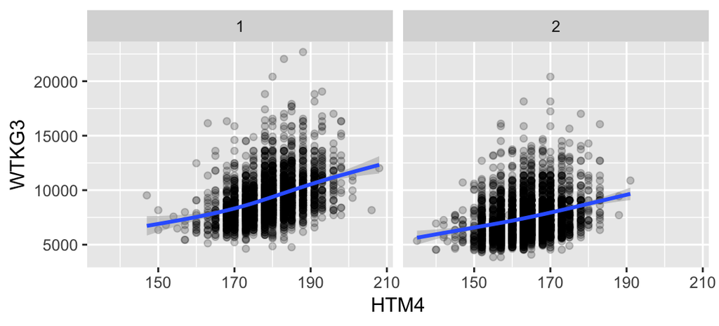

```r
iowa %>%
  ggplot(aes(x = HTM4, y = WTKG3)) + geom_point(alpha = 0.2) +
  facet_grid(.~SEX) +
  geom_smooth()
```

These charts look much better! We see a general increase in weight as height increases. The variability in weight is huge, though. On average, women (`SEX = 2`) are shorter and lighter.

### Correlations of height and weight by gender (Route 2)

Based on variables `HTM4` and `WTKG3`

```r
iowa %>%
  group_by(SEX) %>%
  summarize(
    n = n(),
    cor = cor(HTM4, WTKG3, use="pairwise.complete"),
    non_missing = sum(!is.na(HTM4) & !is.na(WTKG3)),
    non_missing_perc = non_missing/n*100
  )
```

```
## # A tibble: 2 x 5
##     SEX     n   cor non_missing non_missing_perc
##   <int> <int> <dbl>       <int>            <dbl>
## 1     1  2704 0.398        2589             95.7
## 2     2  3523 0.275        3051             86.6
```

## Route 1

This is a bit more work.

```r
# first of all, replace all missing values by NAs
iowa <- iowa %>% mutate(
  HEIGHT3 = replace(HEIGHT3, HEIGHT3 %in% c(7777,9999), NA),
  WEIGHT2 = replace(WEIGHT2, WEIGHT2 %in% c(7777,9999), NA)
)
```

Let’s take on height first:

```r
iowa <- iowa %>% mutate(
  feet = HEIGHT3 %/% 100, # feet and inch only make sense for standard values,
  inch = HEIGHT3 %% 100,  # but we can calculated them for all
  height = ifelse(HEIGHT3 >= 9000,
                  HEIGHT3 - 9000, # transform all metric values by subtracting 9000
                  feet *30.48 + 2.54*inch # add feet and inch converted to centimeter
                  )
)
```

### Now plot!

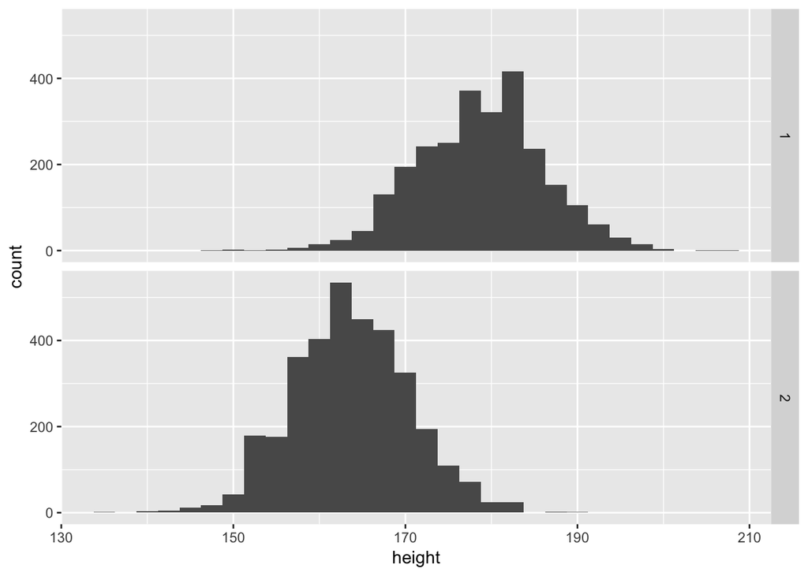

```r
iowa %>% filter(!is.na(height)) %>%
  ggplot(aes(x = height)) + geom_histogram(binwidth = 2.5) +
  facet_grid(SEX~.)
```

We get similar findings - for height at least: women are on average shorter than men.

Now we do the same thing for weight as we did for height before: 1 pound is 0.454 kg

```r
iowa <- iowa %>% mutate(
  weight = ifelse(WEIGHT2 >= 9000,
                  WEIGHT2 - 9000, # transform all metric values by subtracting 9000
                  WEIGHT2*.454 # 1 lbs = 0.454 kg
                  )
)
```

### Correlations of weight and height by gender (Route 1)

```r
iowa %>%
  group_by(SEX) %>%
  summarize(
    n = n(),
    cor = cor(height, weight, use="pairwise.complete"),
    non_missing = sum(!is.na(height) & !is.na(weight)),
    non_missing_perc = non_missing/n*100
  )
```

```
## # A tibble: 2 x 5
##     SEX     n   cor non_missing non_missing_perc
##   <int> <int> <dbl>       <int>            <dbl>
## 1     1  2704 0.398        2589             95.7
## 2     2  3523 0.276        3051             86.6
```

## Recap 2

- the solution is disseminated from an R Markdown document, located at [a github repo](https://github.com/Stat585-at-ISU/materials-2019/tree/master/01_collaborative-environment).
- code and text/documentation are interwoven: reproducible and self-documenting.
- extend or refine analyses by copying and modifying code blocks.
- disseminate your work by sharing the RMarkdown file